# Evaluating the Utility of Synthetic Longitudinal Data Using `synthpop`

Author

Stanley Okafor

Published

December 30, 2025

## 1 Overview

This project presents an exploratory methodological analysis of synthetic data utility using a simulated longitudinal data. The focus is on assessing whether key statistical properties of the original data are preserved after synthesis. Synthetic data were generated using standard workflows as implemented in the `synthpop` package, and utility was evaluated by comparing marginal distributions and joint relationship between the original and synthetic datasets. This approach follows established practice in synthetic data methodology, where utility is assessed by evaluating the extent to which the statistical properties of the original data are preserved in the synthesized data (Nowok et al., 2016).

This project is intended as a practical demonstration of utility evaluation techniques commonly applied when individual-level data are confidential and cannot be shared.

## 2 Skill Demonstrated

- **Synthetic Data Methodology**: Generation and evaluation of synthetic data using established workflows implemented in the `synthpop` package.
- **Utility Assessment**: Evaluation of synthetic data quality using propensity mean squared error (pMSE) and standardized pMSE, including the visual comparison of marginal distributions.
- **Longitudinal & Hierarchical Data Handling**: Working with multi-level longitudinal data having repeated measurements and site-level structure.
- **Parallel Computing in R**: Implementation of parallel computation using the `furrr` package to improve computational efficiency and speed of large datasets.
- **Reproducible Research**: Clear, well-documented Quarto workflow ensuring transparency and reproducibility of results.
- **Statistical Programming in R**: Use of good programming tidyverse-style for data manipulation and functional programming for scalable data workflows.

## 3 Synthesizing and Analyzing Vitamin D Data

The simulated dataset consisted of **38,000 subjects** measured longitudinally, with **two repeated Vitamin D measurements per subject**. Data were collected across **8 different sites**, and includes key covariates such as `Sex`, `Age`, `Time_Outdoors`, as well as identifiers for `Subject_ID` and `Site_ID` allowing for a hierarchical structured data with multi-level variance components `u_site` and `u_subject`.

**Note**

Note:  
1. Implemented parallel processing using `furrr` package which is an extension of `purrr` package. This increases the computation speed by allowing the syntheses to run parallel on multiple CPU cores.  
2. The utility metric `pSME` (probability mean squared error) and its standardized form `S_pMSE`, measures how well the synthetic data preserves the relationships between variables in the original data.

## 4 Load Libraries

```r
library(dplyr)        # Data manipulation
library(synthpop)     # Generate synthetic datasets
library(furrr)        # Parallel processing
library(purrr)
```

## 5 Load and Verify Dataset

load and verify that the original dataset has been loaded successfully.

```r
# Load the dtLong dataset
load("dtLong_big.RData")

# View the first few rows of the dataset
head(dtLong_big)
```

```
  Site_ID   u_site nSubjects Subject_ID u_subject Sex Visit       Age
1       1 1.685683      5071          1 1.1237889   1     1  6.397762
2       1 1.685683      5071          1 1.1237889   1     2 12.397762
3       1 1.685683      5071          2 4.1271229   0     1 10.466640
4       1 1.685683      5071          2 4.1271229   0     2 16.466640
5       1 1.685683      5071          3 0.1294452   0     1  6.004123
6       1 1.685683      5071          3 0.1294452   0     2 12.004123
  Time_Outdoors Vitamin_D_level Deficient
1     3.1624657        48.41067         1
2     4.6708705        61.40135         0
3     0.5077465        62.59722         0
4     2.7836046        52.69414         0
5     1.0468603        26.10149         1
6     2.4056321        53.38100         0
```

The dataset contains longitudinal Vitamin D measurements along with key covariates such as `Sex`, `Age`, `Time_Outdoors`, `Subject_ID` and `Site_ID`.

## 6 Stratified Synthesis of Data by Site_ID

### 6.1 Split the dataset by Site_ID

Here we split the data by Site_ID to perform stratified synthesis of each site separately.

```r
# Split data by Site_ID for stratified synthesis
split_data <- dtLong_big %>%
  group_split(Site_ID)

# View the split data
head(split_data)
```

```
<list_of<
  tbl_df<
    Site_ID        : integer
    u_site         : double
    nSubjects      : double
    Subject_ID     : integer
    u_subject      : double
    Sex            : integer
    Visit          : double
    Age            : double
    Time_Outdoors  : double
    Vitamin_D_level: double
    Deficient      : double
  >
>[6]>
[[1]]
# A tibble: 10,142 × 11
   Site_ID u_site nSubjects Subject_ID u_subject   Sex Visit   Age Time_Outdoors
     <int>  <dbl>     <dbl>      <int>     <dbl> <int> <dbl> <dbl>         <dbl>
 1       1   1.69      5071          1     1.12      1     1  6.40         3.16
 2       1   1.69      5071          1     1.12      1     2 12.4          4.67
 3       1   1.69      5071          2     4.13      0     1 10.5          0.508
 4       1   1.69      5071          2     4.13      0     2 16.5          2.78
 5       1   1.69      5071          3     0.129     0     1  6.00         1.05
 6       1   1.69      5071          3     0.129     0     2 12.0          2.41
 7       1   1.69      5071          4     0.594     1     1  6.98         1.78
 8       1   1.69      5071          4     0.594     1     2 13.0          1.54
 9       1   1.69      5071          5     0.530     1     1  9.88         4.24
10       1   1.69      5071          5     0.530     1     2 15.9          2.16
# ℹ 10,132 more rows
# ℹ 2 more variables: Vitamin_D_level <dbl>, Deficient <dbl>

[[2]]
# A tibble: 8,742 × 11
   Site_ID u_site nSubjects Subject_ID u_subject   Sex Visit   Age Time_Outdoors
     <int>  <dbl>     <dbl>      <int>     <dbl> <int> <dbl> <dbl>         <dbl>
 1       2   6.19      4371       5072     1.12      0     1  4.59         2.66
 2       2   6.19      4371       5072     1.12      0     2 10.6          2.36
 3       2   6.19      4371       5073     1.30      0     1  5.28         5.63
 4       2   6.19      4371       5073     1.30      0     2 11.3          1.12
```

[output cut: 61 more lines]

```
# A tibble: 8,286 × 11
   Site_ID u_site nSubjects Subject_ID u_subject   Sex Visit   Age Time_Outdoors
     <int>  <dbl>     <dbl>      <int>     <dbl> <int> <dbl> <dbl>         <dbl>
 1       6 -0.223      4143      17100     0.772     1     1  6.52        3.21
 2       6 -0.223      4143      17100     0.772     1     2 12.5         5.12
 3       6 -0.223      4143      17101    -2.10      0     1  5.60       -0.0679
 4       6 -0.223      4143      17101    -2.10      0     2 11.6         4.87
 5       6 -0.223      4143      17102    -1.34      1     1  3.30       -0.194
 6       6 -0.223      4143      17102    -1.34      1     2  9.30        2.24
 7       6 -0.223      4143      17103     1.42      0     1  5.46        0.114
 8       6 -0.223      4143      17103     1.42      0     2 11.5         1.94
 9       6 -0.223      4143      17104     0.734     0     1  5.47       -1.65
10       6 -0.223      4143      17104     0.734     0     2 11.5        -0.560
# ℹ 8,276 more rows
# ℹ 2 more variables: Vitamin_D_level <dbl>, Deficient <dbl>
```

### 6.2 Extract constant columns

Basically, synthpop is able to detect the structure and data type of variables, including factors and numeric types, if they are not explicitly defined before synthesis. It is also able to exclude constants variables during synthesis. This has be done here to overcome computational overload to improve the speed and utility of the synthetic data.

```r
# Extract the constant columns to add back later
constant_columns_list <- map(split_data, ~ select(.x, Site_ID, u_site, nSubjects))
```

### 6.3 Synthesis the Data Excluding Constants

This step performs synthesis on the data excluding the constant columns. Random forest method (rf) a tree-based method is used as the synthesizing model for synthesis. Random forest was used for its capability to capture complex relationships.

**Note**

Note:  
`Synthpop` enables sequential conditional modeling as implemented by Nowok et al. 2016, and the synthetic data generation code was implemented following the key guidelines as proposed by Raab et al. (2021).

```r
# Step 1: Set up the parallel processing strategy (e.g., multisession for local machines)
plan(multisession, workers = availableCores() - 1)  # Use all but 1 core

# Parallel synthesis excluding the constants Site_ID, u_site, nSubjects
synth_data_list <- future_map(split_data, ~ {

  # Exclude constants from the data before synthesis
  pre_synthesis_data <- .x %>%
    select(-Site_ID, -u_site, -nSubjects)

  # Perform synthesis using random forest (rf) method
  syn(
    pre_synthesis_data,
    method = "rf",  # Using random forest
    m = 1,
    visit.sequence = c(
      "Subject_ID", "u_subject", "Sex", "Visit", "Age",
      "Time_Outdoors", "Vitamin_D_level", "Deficient"
    ),  # Exclude constants from the visit sequence
    drop.not.used = FALSE,
    proper = TRUE,
    minnumlevels = 2,
    seed = 282721  # Set seed for reproducibility
  )$syn  # Extract the synthesized data
}, .options = furrr_options(seed = TRUE))  # Ensure parallel-safe random number generation
```

[output not shown]

```r
# Reset the plan to sequential processing when done
plan(sequential)
```

### 6.4 Combine Synthesized Data with Constant Columns

Now, we combine the synthesized data with the constant ones without duplicating them.

```r
# Combine synthesized data and constant columns WITHOUT duplicates
combined_synth_data <- map2(constant_columns_list, synth_data_list, ~ {
  # Only bind together columns that don't overlap
  bind_cols(.x, .y)
}) %>%
  bind_rows()

# View the final synthetic dataset
head(combined_synth_data)
```

```
# A tibble: 6 × 11
  Site_ID u_site nSubjects Subject_ID u_subject   Sex Visit   Age Time_Outdoors
    <int>  <dbl>     <dbl>      <int>     <dbl> <dbl> <dbl> <dbl>         <dbl>
1       1   1.69      5071       4230    0.0314     1     2 16.1         0.915
2       1   1.69      5071        592    0.883      0     2 13.7         1.07
3       1   1.69      5071       1552    0.730      0     1  6.71        2.82
4       1   1.69      5071        624   -2.66       1     1 15.6        -2.06
5       1   1.69      5071       1815   -0.664      1     2  9.14        0.658
6       1   1.69      5071        244   -1.12       1     2 12.1        -0.0498
# ℹ 2 more variables: Vitamin_D_level <dbl>, Deficient <dbl>
```

## 7 Align Data Types

To ensure consistency of datatypes between the synthesized and original data, we convert the relevant variables in both datasets to factors.

### 7.1 Convert Variables (Sex, Visit, Deficient) to Factors

```r
# Convert the relevant variables in dtLong to factors to match the synthesized data
dtLong_big <- dtLong_big %>%
  mutate(
    Sex = as.factor(Sex),       # Convert to factor
    Visit = as.factor(Visit),   # Convert to factor
    Deficient = as.factor(Deficient)  # Convert to factor
  )

# Ensure data types align with synthesized data
combined_synth_data <- combined_synth_data %>%
  mutate(
    Sex = as.factor(Sex),       # Ensure these are factors
    Visit = as.factor(Visit),
    Deficient = as.factor(Deficient)
  )

# Ensure the datasets are data frames, not data.table
combined_synth_data <- as.data.frame(combined_synth_data)
dtLong_big <- as.data.frame(dtLong_big)
```

### 7.2 Verify Structure Alignment

Checking the structure of both datasets to ensure that they match.

```r
# Ensure the datasets are data frames, not data.table
combined_synth_data <- as.data.frame(combined_synth_data)
dtLong_big <- as.data.frame(dtLong_big)

# Check if the structure matches after converting to data.frame
str(combined_synth_data)
```

```
'data.frame':   76000 obs. of  11 variables:
 $ Site_ID        : int  1 1 1 1 1 1 1 1 1 1 ...
 $ u_site         : num  1.69 1.69 1.69 1.69 1.69 ...
 $ nSubjects      : num  5071 5071 5071 5071 5071 ...
 $ Subject_ID     : int  4230 592 1552 624 1815 244 4801 4201 2041 2903 ...
 $ u_subject      : num  0.0314 0.8832 0.7296 -2.6561 -0.6643 ...
 $ Sex            : Factor w/ 2 levels "0","1": 2 1 1 2 2 2 1 1 1 2 ...
 $ Visit          : Factor w/ 2 levels "1","2": 2 2 1 1 2 2 2 1 1 2 ...
 $ Age            : num  16.12 13.69 6.71 15.62 9.14 ...
 $ Time_Outdoors  : num  0.915 1.068 2.822 -2.065 0.658 ...
 $ Vitamin_D_level: num  40.5 63.9 45.8 45.7 38.1 ...
 $ Deficient      : Factor w/ 2 levels "0","1": 2 1 2 2 2 2 1 1 2 2 ...
```

```r
str(dtLong_big)
```

```
'data.frame':   76000 obs. of  11 variables:
 $ Site_ID        : int  1 1 1 1 1 1 1 1 1 1 ...
 $ u_site         : num  1.69 1.69 1.69 1.69 1.69 ...
 $ nSubjects      : num  5071 5071 5071 5071 5071 ...
 $ Subject_ID     : int  1 1 2 2 3 3 4 4 5 5 ...
 $ u_subject      : num  1.124 1.124 4.127 4.127 0.129 ...
 $ Sex            : Factor w/ 2 levels "0","1": 2 2 1 1 1 1 2 2 2 2 ...
 $ Visit          : Factor w/ 2 levels "1","2": 1 2 1 2 1 2 1 2 1 2 ...
 $ Age            : num  6.4 12.4 10.5 16.5 6 ...
 $ Time_Outdoors  : num  3.162 4.671 0.508 2.784 1.047 ...
 $ Vitamin_D_level: num  48.4 61.4 62.6 52.7 26.1 ...
 $ Deficient      : Factor w/ 2 levels "0","1": 2 1 1 1 2 1 2 1 1 2 ...
 - attr(*, ".internal.selfref")=<externalptr>
```

## 8 Utility Comparison of Original and Synthesized Dataset

The utility of the synthetic data is evaluated using the propensity mean squared error (pMSE) and its standardized form, the standard pMSE (S_pMSE) both implemented in the **comparison** and **utility.gen** function from the synthpop package to assess how similar the synthesized data is to the original data.

**Note**

Note: According to Nowok et al.(2016), an `pSME` or utility metric of less than or equal to `10` is generally considered an indicator of `high utility`. This means that the synthetic data closely approximates the original data in terms of preserving the relationships between variables.

```
Synthetic and original data checked with synorig.compare,
 looks like no adjustment needed

Calculations done for Site_ID
Calculations done for u_site
Calculations done for nSubjects
Calculations done for Subject_ID
Calculations done for u_subject
Calculations done for Sex
Calculations done for Visit
Calculations done for Age
Calculations done for Time_Outdoors
Calculations done for Vitamin_D_level
Calculations done for Deficient
```

```
Comparing percentages observed with synthetic
```

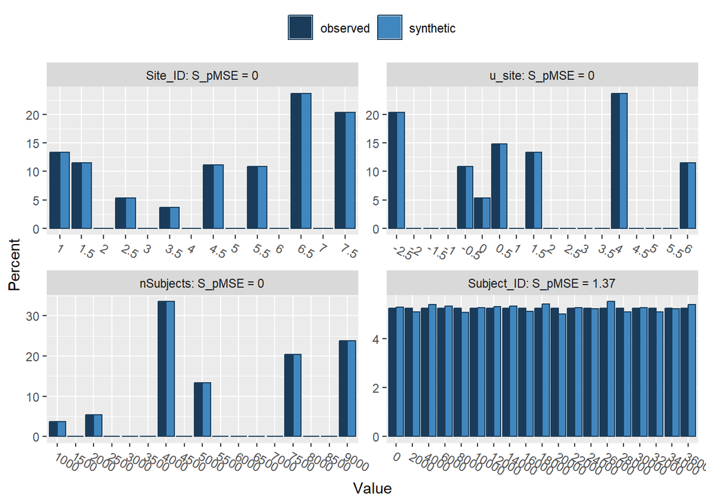

```
Press return for next variable(s):
```

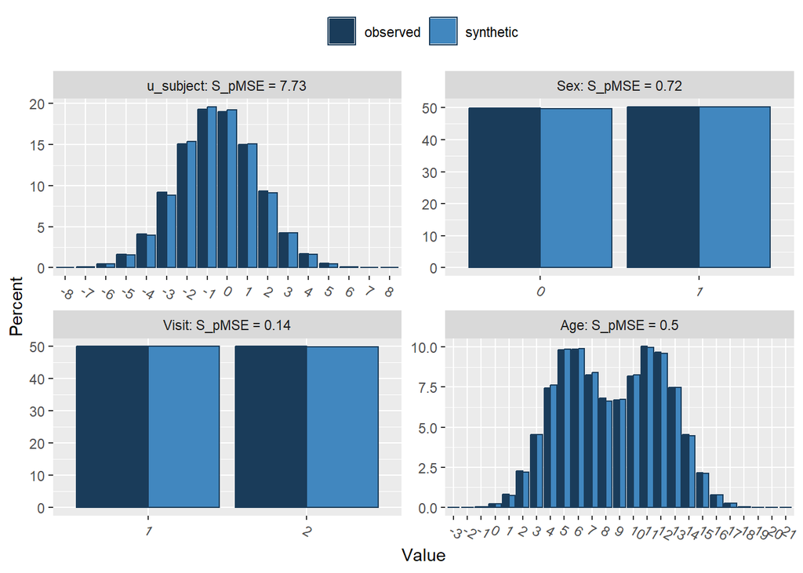

```
Press return for next variable(s):
```

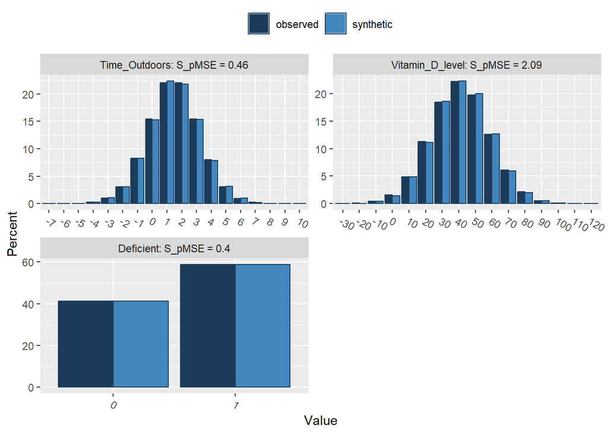

```
Selected utility measures:
                   pMSE   S_pMSE df
Site_ID         0.0e+00 0.000000  3
u_site          0.0e+00 0.000000  3
nSubjects       0.0e+00 0.000000  3
Subject_ID      5.0e-06 1.370573  4
u_subject       2.5e-05 7.726427  4
Sex             1.0e-06 0.720494  1
Visit           0.0e+00 0.142316  1
Age             2.0e-06 0.496184  4
Time_Outdoors   2.0e-06 0.459400  4
Vitamin_D_level 7.0e-06 2.089037  4
Deficient       0.0e+00 0.401687  1
```

```r
compare(combined_synth_data, dtLong_big)
```

```r
u_ob_synth <- utility.gen(combined_synth_data, dtLong_big, method = "cart", resamp.method = "none", print.flag = FALSE)
```

```
Synthetic and original data checked with synorig.compare,
 looks like no adjustment needed
```

```r
u_ob_synth
```

```
Utility score calculated by method: cart

Call:
utility.gen.data.frame(object = combined_synth_data, data = dtLong_big,
    method = "cart", resamp.method = "none", print.flag = FALSE)

Selected utility measures
    pMSE   S_pMSE
0.011313       NA
```

The resulting pMSE and S_pMSE values were consistently small, indicating that the synthetic data closely preserved the key statistical properties to the original data across all variables. Also, the visual comparisons further show that the synthetic data closely preserved the original marginal distributions from all key variables.

In conclusion, this exploratory analysis on the utility of the synthetic data demonstrates that the applied synthetic data workflow was able to generate high utility synthetic data for a complex longitudinal, multi-site setting. While this project specifically focused on the general utility of the synthetic data, further extension could incorporate inferential validity and disclosure risk assessment to provide a more comprehensive evaluation on the quality of the synthetic data.